# # Loans, Bankers and Delinquencies by Ken Musante, DAND Student

For my project I chose the ‘prosperLoanData’. I am in the financial services industry and have worked for three different banks in my lifetime. In looking at the data file, loans has 113,937 observations and 81 variables.

# Look at the Data

81 variables is too many to explore so I’ll need to review them first. Many of the variables appear to have NA or are empty so I’ll avoid those if pracitcal.

```
##                ListingKey ListingNumber           ListingCreationDate
## 1 1021339766868145413AB3B        193129 2007-08-26 19:09:29.263000000
## 2 10273602499503308B223C1       1209647 2014-02-27 08:28:07.900000000
## 3 0EE9337825851032864889A         81716 2007-01-05 15:00:47.090000000
## 4 0EF5356002482715299901A        658116 2012-10-22 11:02:35.010000000
## 5 0F023589499656230C5E3E2        909464 2013-09-14 18:38:39.097000000
## 6 0F05359734824199381F61D       1074836 2013-12-14 08:26:37.093000000
##   CreditGrade Term LoanStatus          ClosedDate BorrowerAPR BorrowerRate
## 1           C   36  Completed 2009-08-14 00:00:00     0.16516       0.1580
## 2               36    Current                         0.12016       0.0920
## 3          HR   36  Completed 2009-12-17 00:00:00     0.28269       0.2750
## 4               36    Current                         0.12528       0.0974
## 5               36    Current                         0.24614       0.2085
## 6               60    Current                         0.15425       0.1314
##   LenderYield EstimatedEffectiveYield EstimatedLoss EstimatedReturn
```

[output cut: 174 more lines]

```
##                    ListingKey     ListingNumber
##  17A93590655669644DB4C06:     6   Min.   :      4
##  349D3587495831350F0F648:     4   1st Qu.: 400919
##  47C1359638497431975670B:     4   Median : 600554
##  8474358854651984137201C:     4   Mean   : 627886
##  DE8535960513435199406CE:     4   3rd Qu.: 892634
##  04C13599434217079754AEE:     3   Max.   :1255725
##  (Other)                :113912
##                     ListingCreationDate  CreditGrade         Term
##  2013-10-02 17:20:16.550000000:     6          :84984   Min.   :12.00
##  2013-08-28 20:31:41.107000000:     4   C      : 5649   1st Qu.:36.00
##  2013-09-08 09:27:44.853000000:     4   D      : 5153   Median :36.00
##  2013-12-06 05:43:13.830000000:     4   B      : 4389   Mean   :40.83
##  2013-12-06 11:44:58.283000000:     4   AA     : 3509   3rd Qu.:36.00
##  2013-08-21 07:25:22.360000000:     3   HR     : 3508   Max.   :60.00
##  (Other)                      :113912   (Other): 6745
##                  LoanStatus                  ClosedDate
##  Current              :56576                      :58848
##  Completed            :38074   2014-03-04 00:00:00:  105
##  Chargedoff           :11992   2014-02-19 00:00:00:  100
##  Defaulted            : 5018   2014-02-11 00:00:00:   92
##  Past Due (1-15 days) :  806   2012-10-30 00:00:00:   81
##  Past Due (31-60 days):  363   2013-02-26 00:00:00:   78
##  (Other)              : 1108   (Other)            :54633
##   BorrowerAPR       BorrowerRate     LenderYield
##  Min.   :0.00653   Min.   :0.0000   Min.   :-0.0100
##  1st Qu.:0.15629   1st Qu.:0.1340   1st Qu.: 0.1242
##  Median :0.20976   Median :0.1840   Median : 0.1730
##  Mean   :0.21883   Mean   :0.1928   Mean   : 0.1827
##  3rd Qu.:0.28381   3rd Qu.:0.2500   3rd Qu.: 0.2400
##  Max.   :0.51229   Max.   :0.4975   Max.   : 0.4925
##  NA's   :25
##  EstimatedEffectiveYield EstimatedLoss   EstimatedReturn
##  Min.   :-0.183          Min.   :0.005   Min.   :-0.183
##  1st Qu.: 0.116          1st Qu.:0.042   1st Qu.: 0.074
##  Median : 0.162          Median :0.072   Median : 0.092
##  Mean   : 0.169          Mean   :0.080   Mean   : 0.096
##  3rd Qu.: 0.224          3rd Qu.:0.112   3rd Qu.: 0.117
##  Max.   : 0.320          Max.   :0.366   Max.   : 0.284
##  NA's   :29084           NA's   :29084   NA's   :29084
```

[output cut: 193 more lines]

```
##  Min.   :    0.00                Min.   :0.7000   Min.   : 0.00000
##  1st Qu.:    0.00                1st Qu.:1.0000   1st Qu.: 0.00000
##  Median :    0.00                Median :1.0000   Median : 0.00000
##  Mean   :   25.14                Mean   :0.9986   Mean   : 0.04803
##  3rd Qu.:    0.00                3rd Qu.:1.0000   3rd Qu.: 0.00000
##  Max.   :21117.90                Max.   :1.0125   Max.   :39.00000
##
##  InvestmentFromFriendsCount InvestmentFromFriendsAmount   Investors
##  Min.   : 0.00000           Min.   :    0.00            Min.   :   1.00
##  1st Qu.: 0.00000           1st Qu.:    0.00            1st Qu.:   2.00
##  Median : 0.00000           Median :    0.00            Median :  44.00
##  Mean   : 0.02346           Mean   :   16.55            Mean   :  80.48
##  3rd Qu.: 0.00000           3rd Qu.:    0.00            3rd Qu.: 115.00
##  Max.   :33.00000           Max.   :25000.00            Max.   :1189.00
##
```

```
##  [1] "ListingKey"
##  [2] "ListingNumber"
##  [3] "ListingCreationDate"
##  [4] "CreditGrade"
##  [5] "Term"
##  [6] "LoanStatus"
##  [7] "ClosedDate"
##  [8] "BorrowerAPR"
##  [9] "BorrowerRate"
## [10] "LenderYield"
## [11] "EstimatedEffectiveYield"
## [12] "EstimatedLoss"
## [13] "EstimatedReturn"
## [14] "ProsperRating..numeric."
## [15] "ProsperRating..Alpha."
```

[output cut: 66 more lines]

# Univariate Plots

surprisingly high number of charged-off loans–perhaps something to look at?

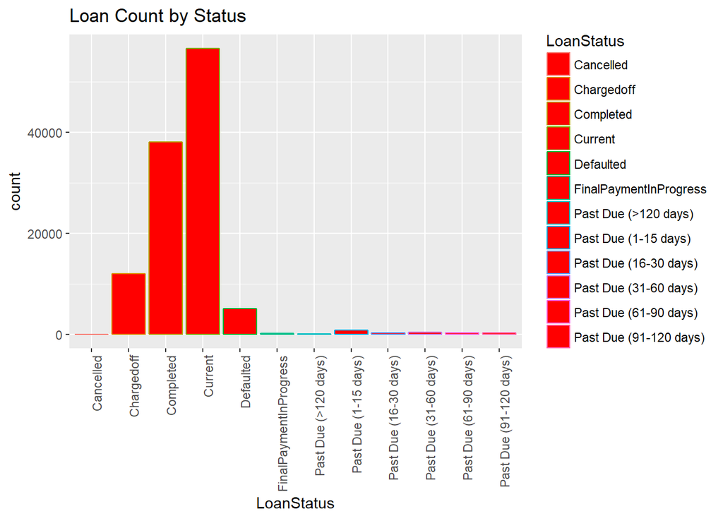

Appears to be little different between UPPER AND LOWER credit scores

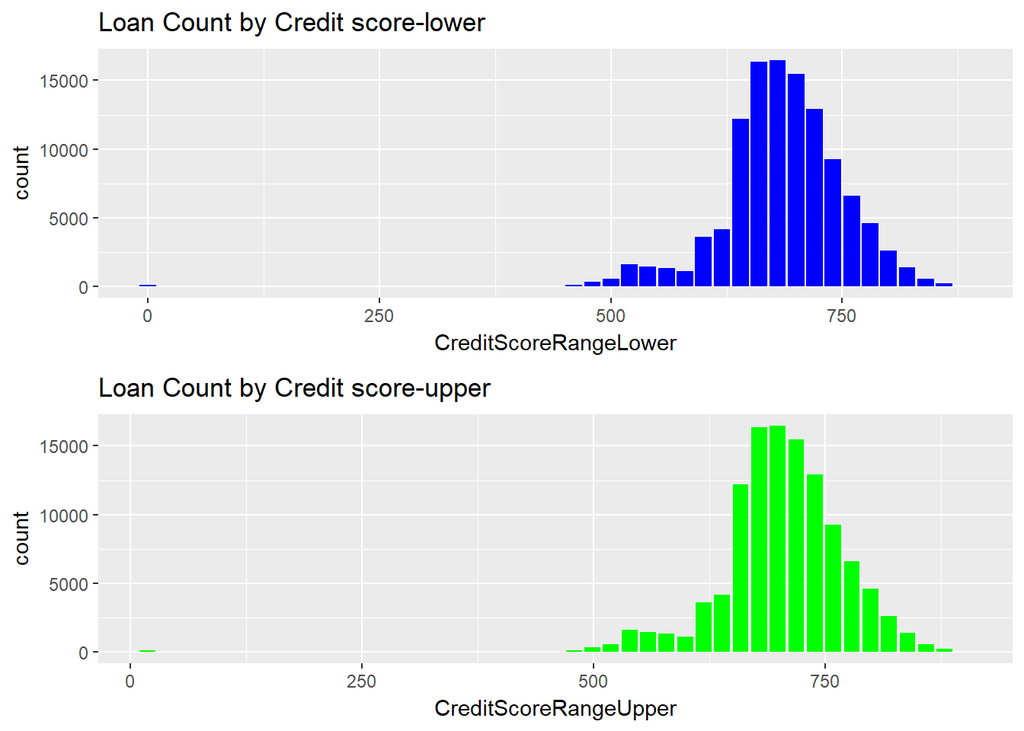

Look at what Charge-offs look like by amount

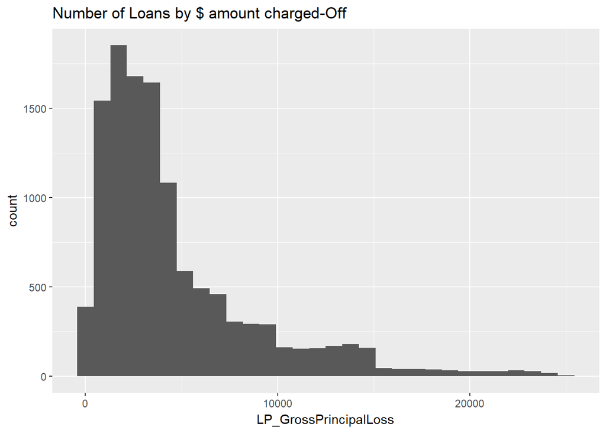

Interesting that some clients have more than 20 revolving accounts

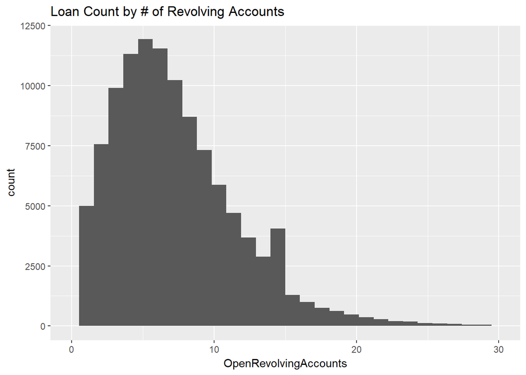

Most loan payments are less than $700/mo

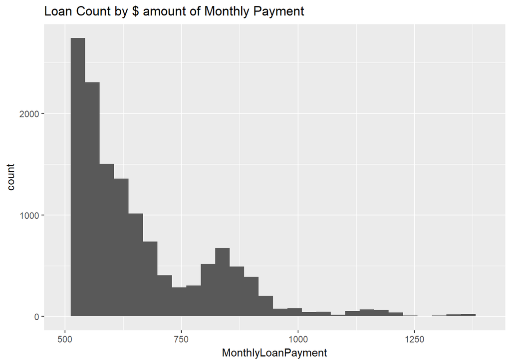

Given High Charge-off, would friends want to invest?

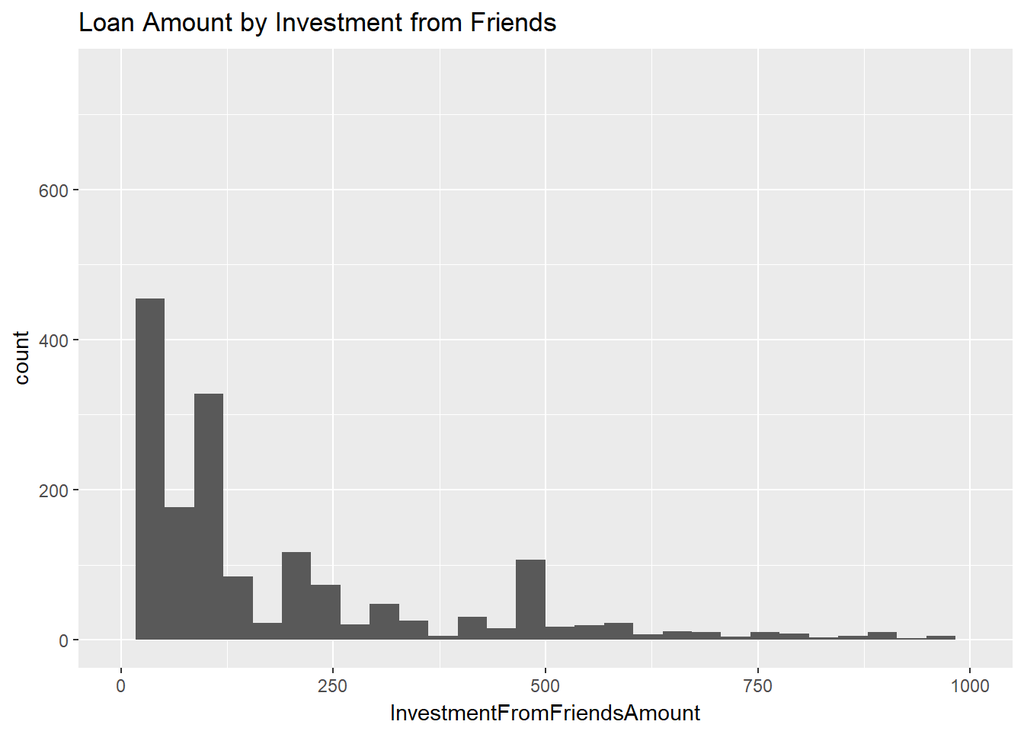

Looks like most borrowers did not have an investment from ‘friends’

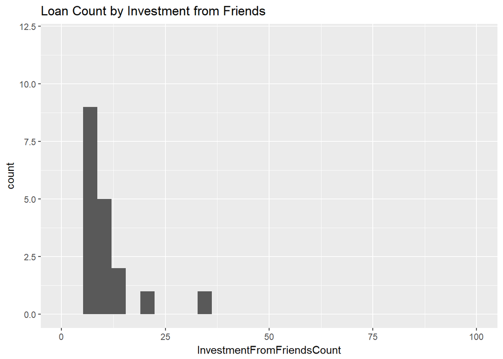

Not an insignificant number of Loans have investors

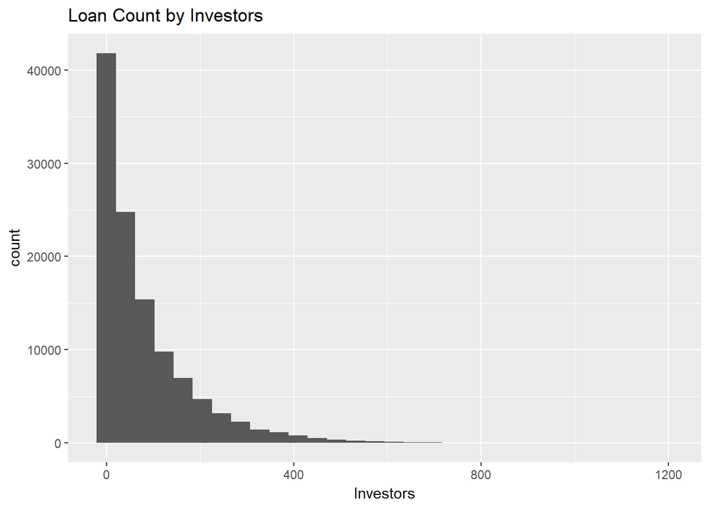

Lots of indivdiauls did not state their mo. income.

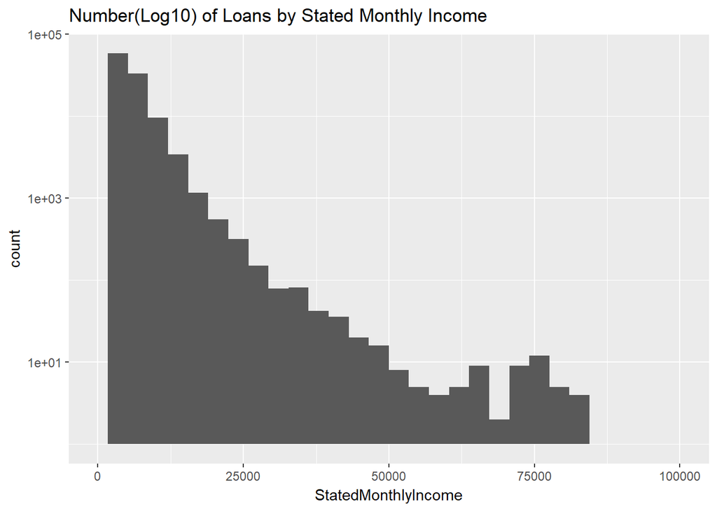

Lenders expecting some high losses…..i wonder what interest rates are??

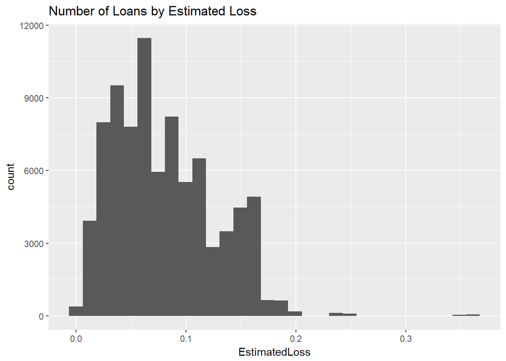

Yields (or rates) look enormously high!!

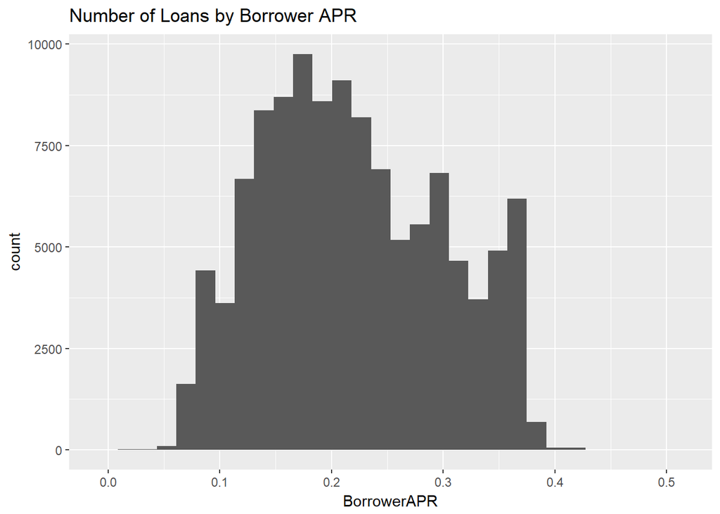

Interesting to see the Return expected with so many Charge-offs

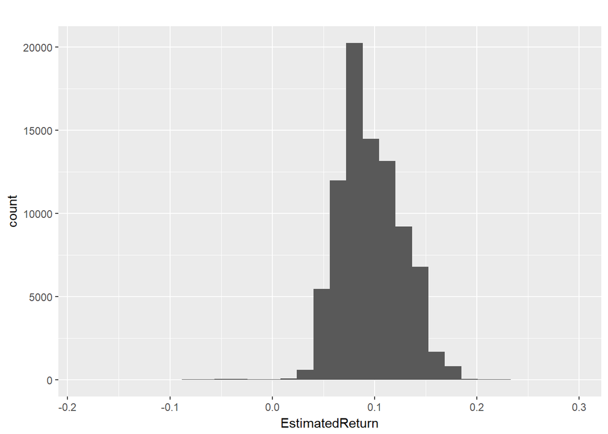

Check to see if Significant Percentage are not employed

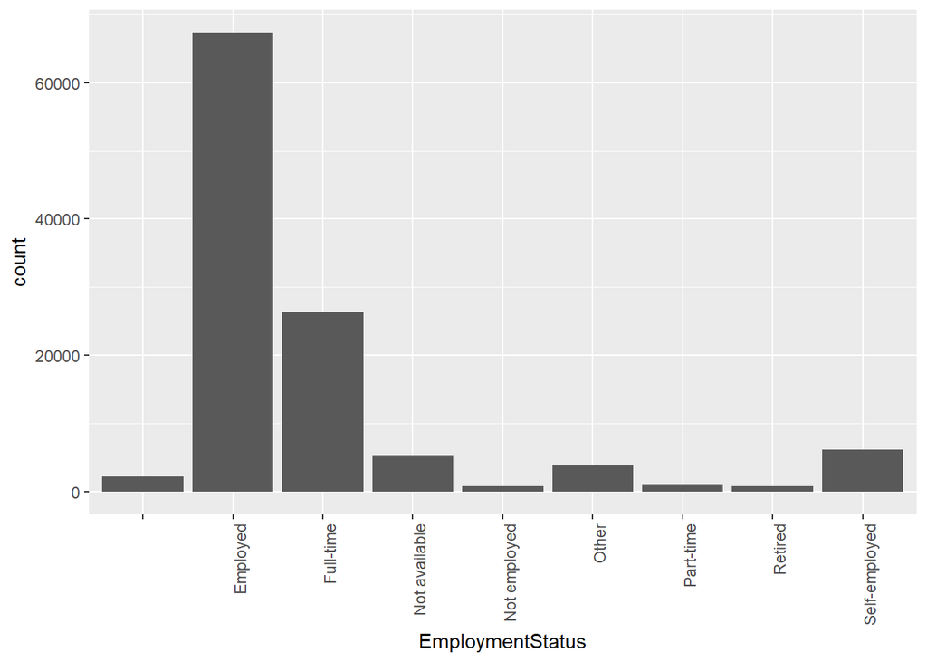

```
## $title
## [1] "Loan Count by EmploymentStatus"
##
## $subtitle
## NULL
##
## attr(,"class")
## [1] "labels"
```

Identify how long borrowers have been employed

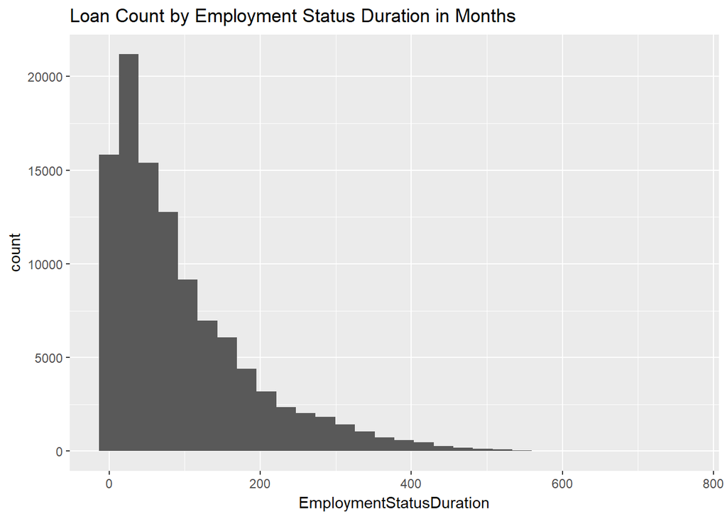

Just over half appear to be homeowners

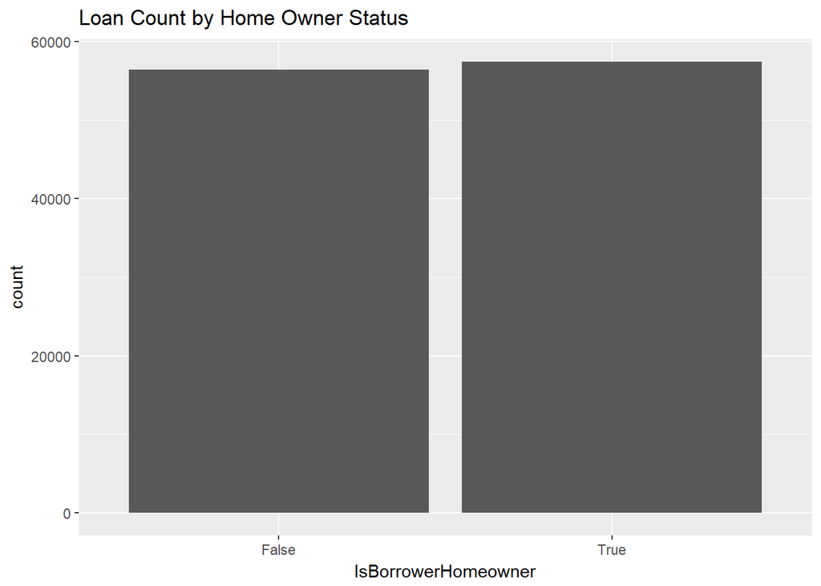

See what Principal loss data looks like

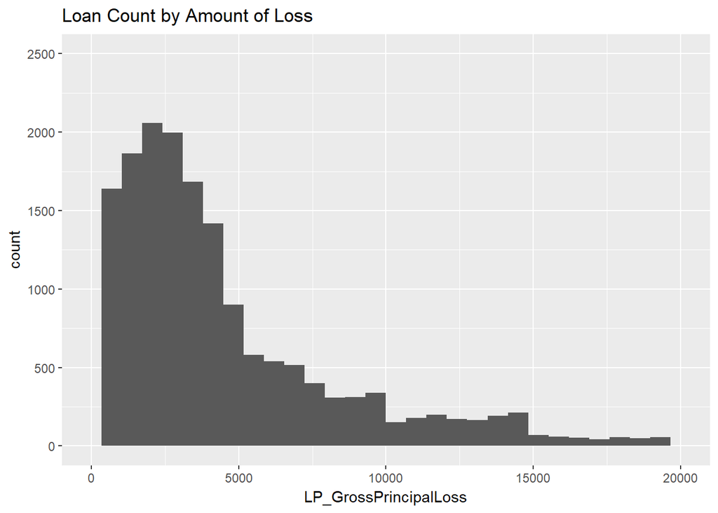

### Listing Categories

The category of the listing that the borrower selected when posting their listing: 0 - Not Available, 1 - Debt Consolidation, 2 - Home Improvement, 3 - Business, 4 - Personal Loan, 5 - Student Use, 6 - Auto, 7 - Other, 8 - Baby&Adoption, 9 - Boat, 10 - Cosmetic Procedure, 11 - Engagement Ring, 12 - Green Loans, 13 - Household Expenses, 14 - Large Purchases, 15 - Medical/Dental, 16 - Motorcycle, 17 - RV, 18 - Taxes, 19 - Vacation, 20 - Wedding Loans

Not surprisingly, Debt Consolodations have a high number of charge-offs

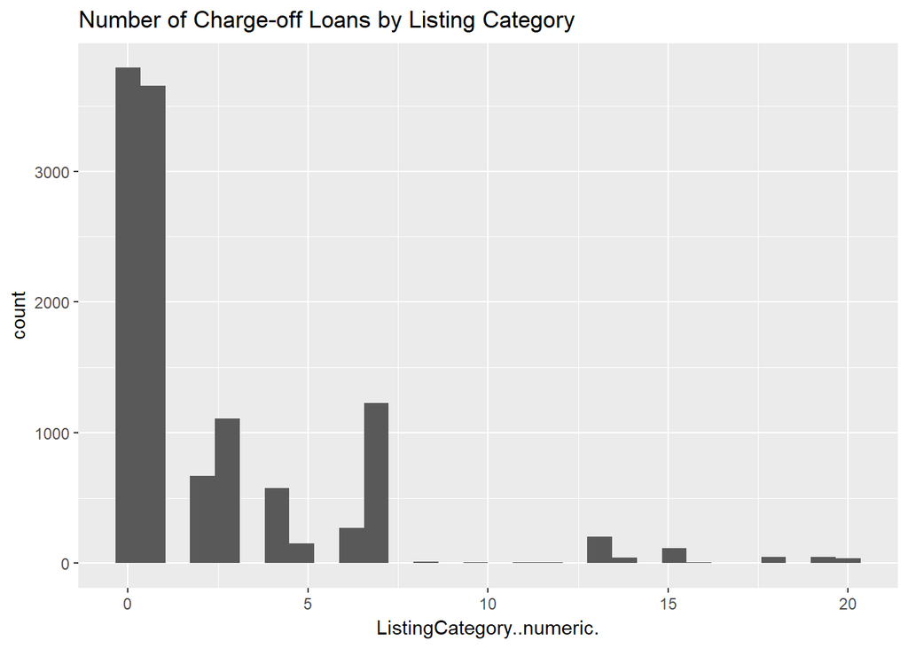

Not surprisingly the number of charge-offs are greater with newly employed

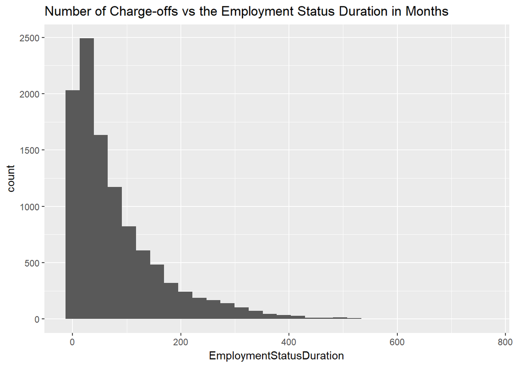

Even zero delinquencies in the past 7 years did not keep Charge-offs at bay.

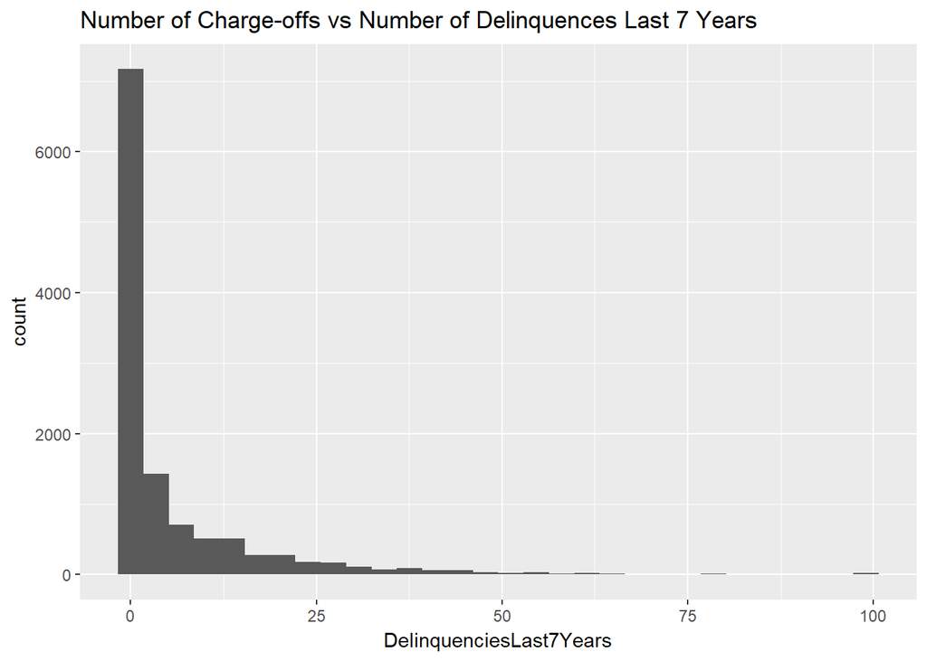

As absolute value, amount of individual charge-offs mostly below $10,000

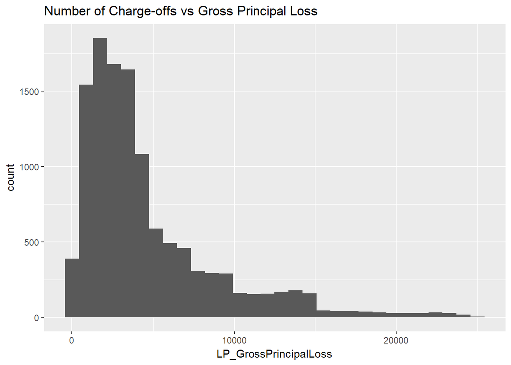

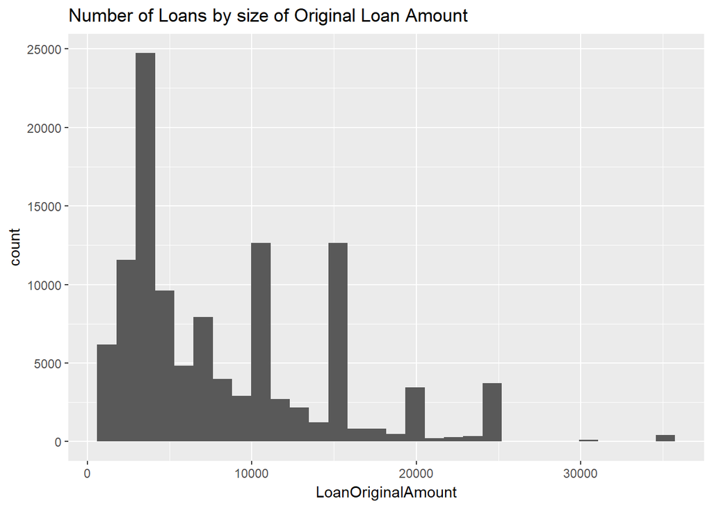

# Univariate Analysis

As mentioned previously, this data set had a lot of variables.  
It was sometimes difficult to determine which variables to plot.

The dataset contained information on nearly 114,000 loan customers.

The Googledocs where the variables are defined can be found here: https://docs.google.com/spreadsheets/d/1gDyi_L4UvIrLTEC6Wri5nbaMmkGmLQBk-Yx3z0XDEtI/edit#gid=0

There are 81 variables. That is a lot of variables on each loan customer. Obviously with this many variables, some are more important than others. ListingKey and other variables which were to track the client number may be important for the lender but do not provide us additional insight. Further, When first looking at the dataset I was struck by the high level of charge-offs and delinquencies. 11,992 Charge-offs.

```
##              Cancelled             Chargedoff              Completed
##                      5                  11992                  38074
##                Current              Defaulted FinalPaymentInProgress
##                  56576                   5018                    205
##   Past Due (>120 days)   Past Due (1-15 days)  Past Due (16-30 days)
##                     16                    806                    265
##  Past Due (31-60 days)  Past Due (61-90 days) Past Due (91-120 days)
##                    363                    313                    304
```

When examining the data further it was apparent that the high charge-offs was commencerent with the high rates charged to the borrowers. The Mean APR is 21.883% and the Median APR is 20.976%!

```
##    Min. 1st Qu.  Median    Mean 3rd Qu.    Max.    NA's
## 0.00653 0.15629 0.20976 0.21883 0.28381 0.51229      25
```

Based on the high charge-offs and high APRs, I looked a number of Variables which would be correlated to delinquencies and Charge- offs including: -LoanStatus -CreditScoreRangeUpper & CreditScoreRangeLower -OpenRevolvingAccounts -MonthlyLoanPayment -InvestmentFromFriendsAmount -Investors -StatedMonthlyIncome -EstimatedLoss -BorrowerAPR -EstimatedReturn -EmploymentStatus -EmploymentStatusDuration -IsBorrwerHomerowner -DelinquenciesLast7Years -LP_GrossPrincipalLoss -ListingCategory..numeric.

Additoinally, because of the number of variables, I avoided variables which were not related to losses or delinquencies as well as variables with too many NA’s such as: -TotalProsperLoans -TotalProsperPaymentsBilled -OnTimeProsperPayments -ProsperPaymentLessThanOneMonthLate -ProsperPaymentsOneMonthPlusLate

The area that I wanted to focus on were losses. The Loans have a high charge-off rate and are priced very high. Certainly the borrowAPR tells us the rates are high. I thought the high charge-offs might be due to the Great Recession given the period identitified in the summary below. Unfortunately, there is not sufficient data points to tell us when the charge-offs began or the dates loans were charged-off so although we can speculate the charge-offs were related to the Great Recession, we have no modeling to base that upon.

```
## [1] Q3 2007 Q1 2014 Q1 2007 Q4 2012 Q3 2013 Q4 2013
## 33 Levels: Q1 2006 Q1 2007 Q1 2008 Q1 2010 Q1 2011 Q1 2012 ... Q4 2013
```

Given the above and number of variables, I did not yet need to create any additional variables but I did subset the loans portfolio quite often so I was only looking that portion of loans which were charged-off. Next I will attempt to evaluate the variables most closely correlated with charge-offs.

# Bivariate Plots Section

I expect higher delinquencies and charge-offs at the higher funded ratios.

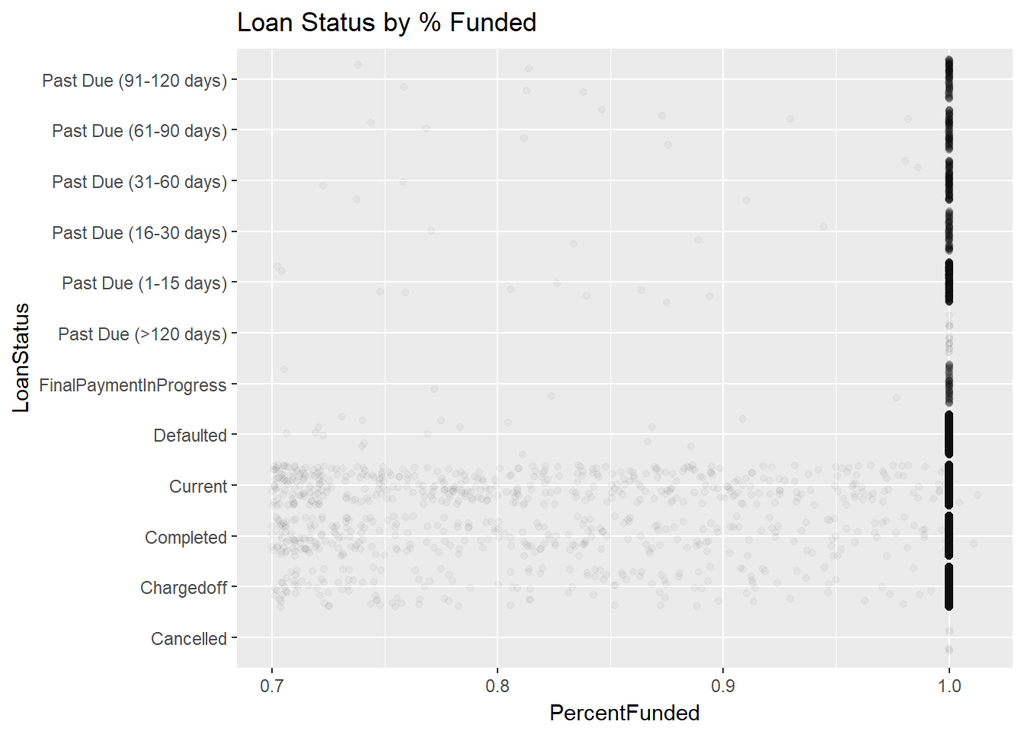

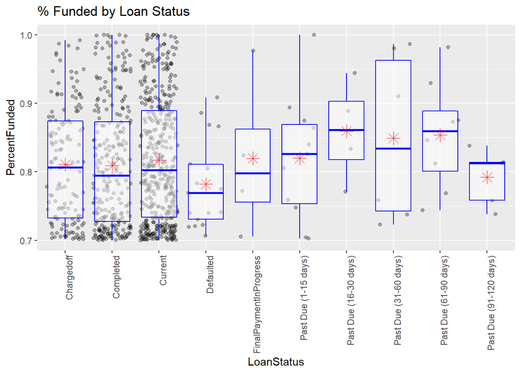

When viewing correlation coefficient there is not a significant correlation between LP_GrossPrincipalLoss & Percent Funded.

```
##
##  Pearson's product-moment correlation
##
## data:  loans$LP_GrossPrincipalLoss and (1 - loans$PercentFunded)
## t = 4.4369, df = 113940, p-value = 9.135e-06
## alternative hypothesis: true correlation is not equal to 0
## 95 percent confidence interval:
##  0.007337619 0.018948669
## sample estimates:
##        cor
## 0.01314359
```

```
## [1] 3317.755
```

```
## [1] 4715.163
```

```
## [1] 4434.95
```

```
## [1] 5804.97
```

Unclear if investments from friends impacts delinquency

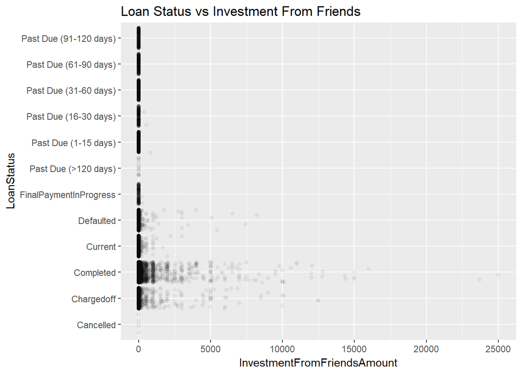

Investment from Friend Amount not strongly correlated

```
##
##  Pearson's product-moment correlation
##
## data:  loans$LP_GrossPrincipalLoss and loans$InvestmentFromFriendsAmount
## t = 9.7125, df = 113940, p-value < 2.2e-16
## alternative hypothesis: true correlation is not equal to 0
## 95 percent confidence interval:
##  0.02295966 0.03456311
## sample estimates:
##        cor
## 0.02876236
```

See if there is a visual correlation between Loan Status & Employment Duration

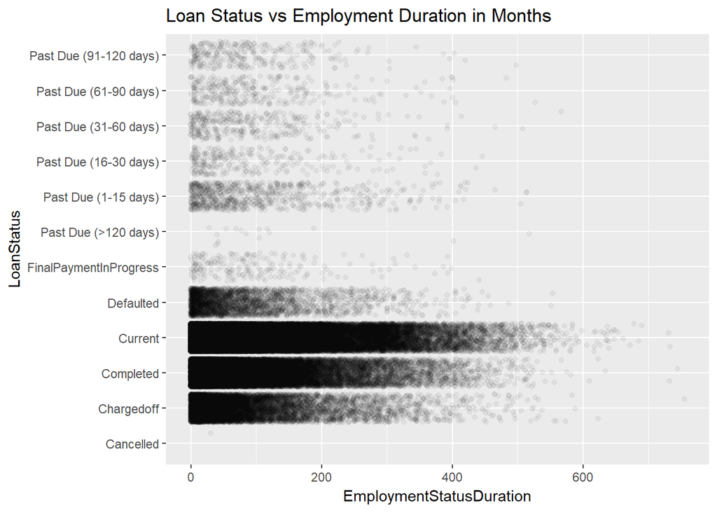

Slight correlation between employment duration and Gross Principalloss

```
##
##  Pearson's product-moment correlation
##
## data:  loans$LP_GrossPrincipalLoss and loans$EmploymentStatusDuration
## t = -11.82, df = 106310, p-value < 2.2e-16
## alternative hypothesis: true correlation is not equal to 0
## 95 percent confidence interval:
##  -0.04223121 -0.03022468
## sample estimates:
##         cor
## -0.03622925
```

Appears to be correlated such that an increse in employment duration leads to higher Gross Principal Loss!!?

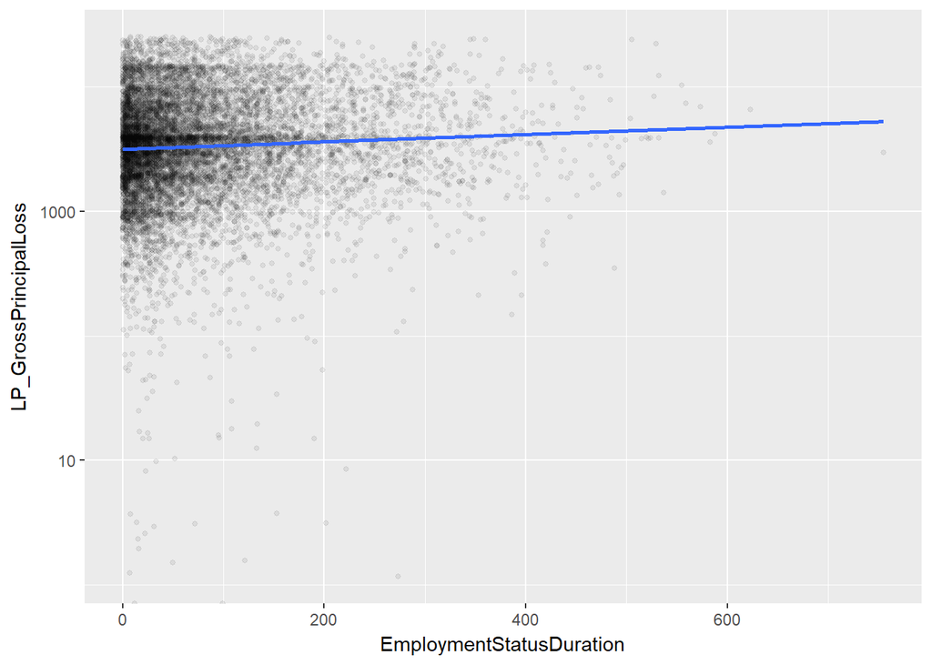

```
## $title
## [1] "Gross Principal Loss vs Employment Duration for Charged-off Loans"
##
## $subtitle
## NULL
##
## attr(,"class")
## [1] "labels"
```

Evaluate Home Owners from Non-homeowners

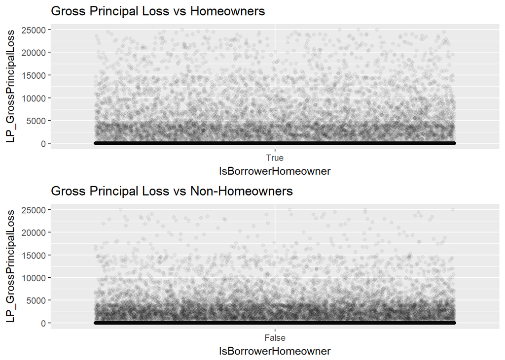

```
## [1] 3912.54
```

```
## [1] 5772.933
```

```
## [1] 2851.58
```

```
## [1] 3873.706
```

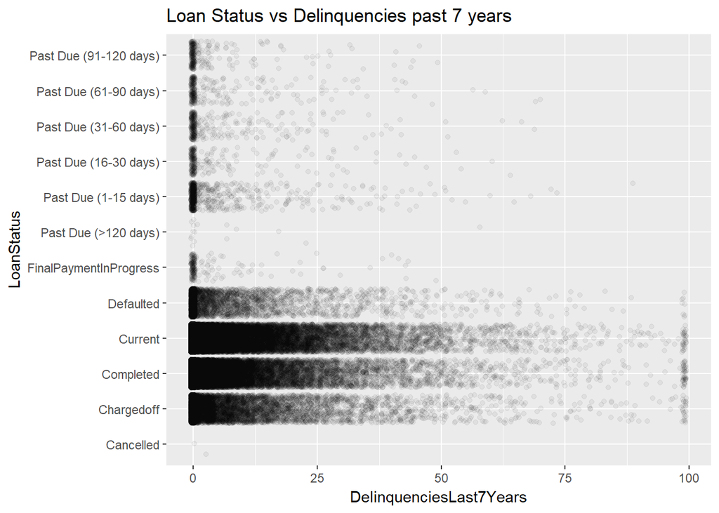

Evaluate if loss is correlated with Listing category

The category of the listing that the borrower selected when posting their listing: 0 - Not Available, 1 - Debt Consolidation, 2 - Home Improvement, 3 - Business, 4 - Personal Loan, 5 - Student Use, 6 - Auto, 7- Other, 8 - Baby&Adoption, 9 - Boat, 10 - Cosmetic Procedure, 11 - Engagement Ring, 12 - Green Loans, 13 - Household Expenses, 14 - Large Purchases, 15 - Medical/Dental, 16 - Motorcycle, 17 - RV, 18 - Taxes, 19 - Vacation, 20 - Wedding Loans

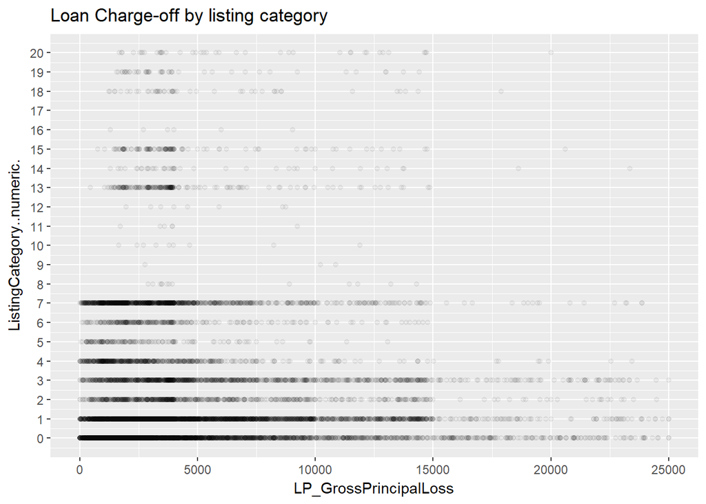

Replot Above graph by ratio. There certainly seems to be some telling information based on the Listing Category. Espeically 1-Debt Consolidation, 3-Business and 7-Other.

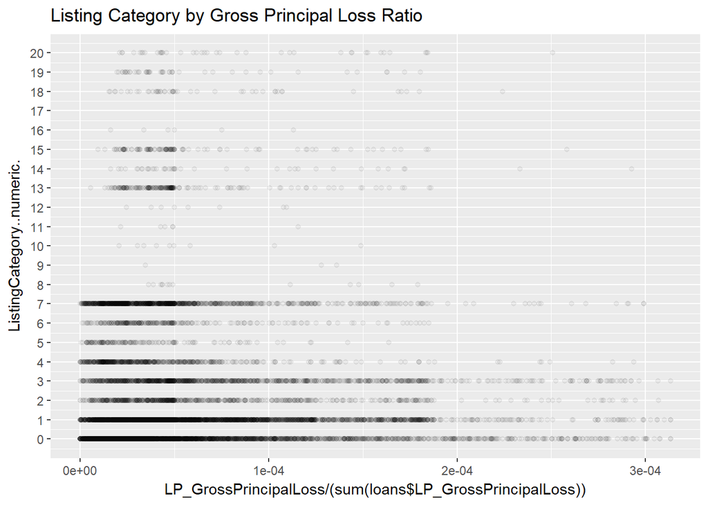

We might be on to something by looking at Listing Category

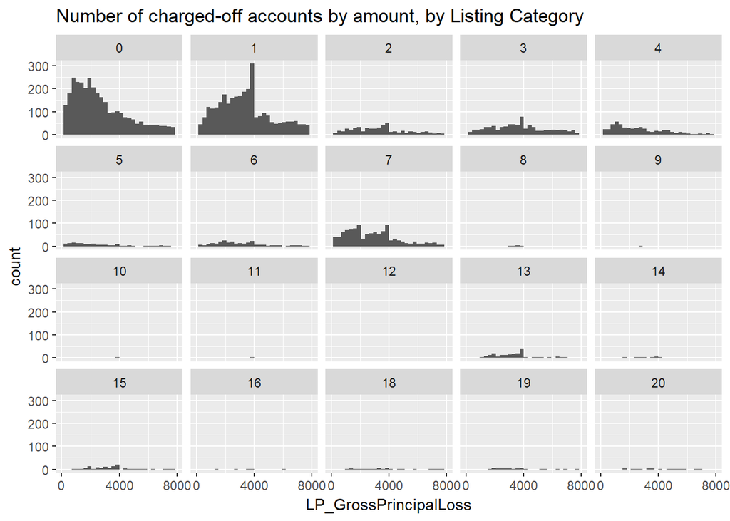

Certainly we should explore this above data set further

Lets look at Credit Score

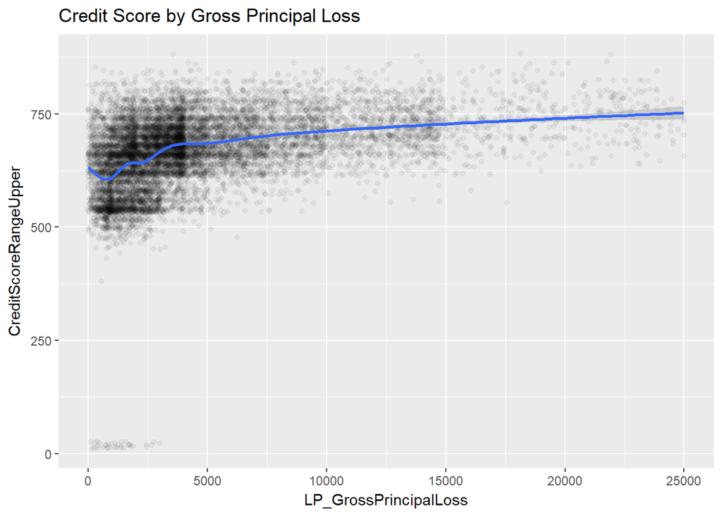

See if there is a correlation as the graph does not appear to support that.

```
##
##  Pearson's product-moment correlation
##
## data:  loans$LP_GrossPrincipalLoss and loans$CreditScoreRangeUpper
## t = -20.592, df = 113340, p-value < 2.2e-16
## alternative hypothesis: true correlation is not equal to 0
## 95 percent confidence interval:
##  -0.0668483 -0.0552484
## sample estimates:
##         cor
## -0.06105041
```

```
## [1] 5109.67
```

```
## [1] 7036.989
```

```
## [1] 2834.41
```

```
## [1] 3840.415
```